# Exercise 10

Group J

29 March 2022

## This exercise links to Module 5.4

Submit the completed exercise to us at:

- t.edwards@usu.edu
- eric_tsakiris@fws.gov

## Context

The data are of the *Pinus edulis* Common piñon, the species you dealt with in Exercise #3 – #5. This exercise relies on the dataframe you generated in exercise #6. Hopefully you saved those combined presence:absence dataframe, with the reduced variables you begin SDHM model construction with, or regrettably you will need to return to exercise #6 and re–build that dataframe.

The goal is to: * Produce and interpret variable importance plots * Build a table of accuracy metrics, and AUC plot * Plot map products of the: * (i) probability; and * (ii) classified distribution model * (Save these two maps as **`.img`** files for use later in the course)

Remember, you will have been assigned data for *edulis* having one the following four discrete labels:

- **Seedlings**: these data indicate spatial locations where seedlings of the tree have been found
- **Mortality**: these data indicate spatial locations where mortality has been observed
- **Persistence**: these data have no observed mortality or seedling at given spatial locations
- **Range**: the total dataset, including all spatial locations of seedlings, mortality, and persistence

## The Data

- The dataframe completed in exercise #6.

## Question #1

- Import and explore data
  - **NOTE**: intent is not to reduce number of variables; that was completed in exercise #5. Rather, calculate simple descriptive statistics (mean, sd, n) and boxplots

```r
path.root <- "D:/OneDrive - University of Vermont/Classes/Spring2022/sdhmR/sdhmR-V2022.1" #Reed Laptop Path
#path.root <- "C:/Users/14842/Documents/SDHM/sdhmR-V2022.1" #Lindsey Path
path.ex <- paste(path.root, "/data/exercise/traindat", sep = "") #Path to mod 2
path.preds <- paste(path.root, '/data/exercise/preds', sep = '')
path.figs <- paste(path.root, "/powerpoints/figures", sep = "") #path to save figs
path.gis <- paste(path.root, "/data/gis_layers", sep = "") #path to gis files

# some libraries
library(raster) # FXNS: extent, raster, res, rasterize, values, writeRaster,
#       cellFromXY, extract
library(sf)     # FXNS: st_as_sf, st_as_sfc, st_bbox, st_convex_hull, st_union
#       st_buffer, st_read, st_write, st_intersection, st_geometry,
#       st_drop_geometry, st_coordinates, st_sf
library(terra)  # FXNS: as.data.frame, rast, vect
library(sp)
library(dplyr)
library(tidyverse)
library(data.table)
library(modeest)
library(DAAG)
library(PresenceAbsence)
options("rgdal_show_exportToProj4_warnings"="none") # run this before library(rgdal)
library(rgdal)
library(dismo)
library(maptools)
library(randomForest)

# source course CRSs
setwd(path.root)
getwd()
```

```
## [1] "D:/OneDrive - University of Vermont/Classes/Spring2022/sdhmR/sdhmR-V2022.1"
```

```r
source("r_code/prjs4_sdhmR.r")
ls(pattern = "prj.") # should be 5 prj.* objects
```

```
## [1] "prj.aeaN83"    "prj.gmerc"     "prj.latlong"   "prj.utmWGSz12"
## [5] "prj.wgs84"
```

```r
# Load functions--------------------------------------

# build model formula as alternative hard code
mod.form <- function(dat ,r.col, p.col) {
  # generic formula construction function; inputs as:
  #  resp =>col 1 in dataframe such that r.col=1,
  #  preds=>col 2 thru ncol in dataframe such that p.col=2
  #  NOTE: predictor vars as factors; coerce PRIOR to formula construction
  # example call: mod.form(dat1,1,2)
  n.col <- ncol(dat) # No. columns in dataframe
  resp <- colnames(dat[r.col]) # assign resp column name
  resp <- paste("as.factor(", colnames(dat[r.col]), ")", sep = "") # assign resp column name
  pred <- colnames(dat[c(p.col:n.col)]) # assign preds column names
  mod.formula <- as.formula(paste(resp, "~", paste(pred, collapse = "+"))) # build formula
}
```

```r
# Global Variables-------------------------------------
setwd(path.ex)
load('tr_PERS.RData')
class(tr_PERS)
```

```
## [1] "data.frame"
```

```r
head(tr_PERS)
```

```
##   FNETID PERS106 wgs_xF wgs_yF exp5nrm exp3nrm rough_1k prad_sw_di etpt_5
## 1    194       0     NA     NA      NA      NA       NA         NA     NA
## 2   1922       0     NA     NA      NA      NA       NA         NA     NA
## 3   3813       0     NA     NA      NA      NA       NA         NA     NA
## 4   5186       0     NA     NA      NA      NA       NA         NA     NA
## 5   5594       0     NA     NA      NA      NA       NA         NA     NA
## 6   6226       0     NA     NA      NA      NA       NA         NA     NA
##   mind_yr_av prec_winte tave_sprin UNIQUEID.x cell.wgs_x cell.wgs_y UNIQUEID.y
## 1         NA         NA         NA       <NA>  -112.9988   42.14331       <NA>
## 2         NA         NA         NA       <NA>  -110.6498   42.13498       <NA>
## 3         NA         NA         NA       <NA>  -106.9429   42.12665       <NA>
## 4         NA         NA         NA       <NA>  -107.5510   42.11832       <NA>
## 5         NA         NA         NA       <NA>  -104.1524   42.11832       <NA>
## 6         NA         NA         NA       <NA>  -110.9330   42.10999       <NA>
##    tr.wgs_x tr.wgs_y etpt_5.img etpt_6.img etpt_sprin.img mind_yr_av.img
## 1 -112.9988 42.14331         NA         NA             NA             NA
## 2 -110.6498 42.13498         81         95       27.00000       -866.750
## 3 -106.9429 42.12665         90         99       51.66667      -1162.417
## 4 -107.5510 42.11832         88         98       49.00000      -1144.833
## 5 -104.1524 42.11832         92        101       68.33334      -1299.583
## 6 -110.9330 42.10999         87         97       47.33333      -1092.000
##   prec_winte.img tave_s_hal.img tave_sprin.img tmax_s_hal.img tmax_summe.img
## 1             NA             NA             NA             NA             NA
## 2       26.33333        93.0000      -1.333333       185.0000       225.0000
## 3       17.00000       135.5000      38.333332       213.1667       256.3333
## 4       13.66667       127.3333      31.333334       209.6667       253.0000
## 5        8.00000       163.5000      75.000000       257.6667       299.0000
## 6       21.00000       115.3333      24.000000       211.3333       251.3333
```

```r
drops <- c('wgs_xF','wgs_yF','cell.wgs_x','cell.wgs_y','exp5nrm','exp3nrm','rough_1k','prad_sw_di',
           'etpt_5','mind_yr_av','prec_winte','tave_sprin','UNIQUEID.x'
           ,'UNIQUEID.y')
tr_PERS <- tr_PERS[ ,!(names(tr_PERS) %in% drops)]
tr_PERS <- na.omit(tr_PERS)
dim(tr_PERS)
```

```
## [1] 1942   13
```

```r
#explore etpt5
mean(tr_PERS$etpt_5.img, na.rm = T) #mean returned NA
```

```
## [1] 92.35839
```

```r
sum(is.na(tr_PERS$etpt_5.img)) #checked for number of NAs
```

```
## [1] 0
```

```r
sd(tr_PERS$etpt_5.img, na.rm = T) #standard deviation
```

```
## [1] 5.560058
```

```r
nrow(tr_PERS) - sum(is.na(tr_PERS$etpt_5.img)) #check total N
```

```
## [1] 1942
```

```r
#explore etpt6
mean(tr_PERS$etpt_6.img, na.rm = T) #mean returned NA
```

```
## [1] 100.0278
```

```r
sum(is.na(tr_PERS$etpt_6.img)) #checked for number of NAs
```

```
## [1] 0
```

```r
sd(tr_PERS$etpt_6.img, na.rm = T) #standard deviation
```

```
## [1] 2.18426
```

```r
nrow(tr_PERS) - sum(is.na(tr_PERS$etpt_6.img)) #check total N
```

```
## [1] 1942
```

```r
#explore etpt_sprin
mean(tr_PERS$etpt_sprin.img, na.rm = T) #mean returned NA
```

```
## [1] 69.36011
```

```r
sum(is.na(tr_PERS$etpt_sprin.img)) #checked for number of NAs
```

```
## [1] 0
```

```r
sd(tr_PERS$etpt_sprin.img, na.rm = T) #standard deviation
```

```
## [1] 14.20613
```

```r
nrow(tr_PERS) - sum(is.na(tr_PERS$etpt_sprin.img)) #check total N
```

```
## [1] 1942
```

```r
#explore mind_yr_ave
mean(tr_PERS$mind_yr_av.img, na.rm = T) #mean returned NA
```

```
## [1] -1441.124
```

```r
sum(is.na(tr_PERS$mind_yr_av.img)) #checked for number of NAs
```

```
## [1] 0
```

```r
sd(tr_PERS$mind_yr_av.img, na.rm = T) #standard deviation
```

```
## [1] 334.7886
```

```r
nrow(tr_PERS) - sum(is.na(tr_PERS$mind_yr_av.img)) #check total N
```

```
## [1] 1942
```

```r
#explore prec_winte
mean(tr_PERS$prec_winte.img, na.rm = T) #mean returned NA
```

```
## [1] 23.29059
```

```r
sum(is.na(tr_PERS$prec_winte.img)) #checked for number of NAs
```

```
## [1] 0
```

```r
sd(tr_PERS$prec_winte.img, na.rm = T) #standard deviation
```

```
## [1] 12.59748
```

```r
nrow(tr_PERS) - sum(is.na(tr_PERS$prec_winte.img)) #check total N
```

```
## [1] 1942
```

```r
#explore tave_s_hal
mean(tr_PERS$tave_s_hal.img, na.rm = T) #mean returned NA
```

```
## [1] 169.3242
```

```r
sum(is.na(tr_PERS$tave_s_hal.img)) #checked for number of NAs
```

```
## [1] 0
```

```r
sd(tr_PERS$tave_s_hal.img, na.rm = T) #standard deviation
```

```
## [1] 42.62714
```

```r
nrow(tr_PERS) - sum(is.na(tr_PERS$tave_s_hal.img)) #check total N
```

```
## [1] 1942
```

```r
#explore tave_sprin
mean(tr_PERS$tave_sprin.img, na.rm = T) #mean returned NA
```

```
## [1] 86.88345
```

```r
sum(is.na(tr_PERS$tave_sprin.img)) #checked for number of NAs
```

```
## [1] 0
```

```r
sd(tr_PERS$tave_sprin.img, na.rm = T) #standard deviation
```

```
## [1] 47.30311
```

```r
nrow(tr_PERS) - sum(is.na(tr_PERS$tave_sprin.img)) #check total N
```

```
## [1] 1942
```

```r
#explore tmax_summe
mean(tr_PERS$tmax_summe.img, na.rm = T) #mean returned NA
```

```
## [1] 290.372
```

```r
sum(is.na(tr_PERS$tmax_summe.img)) #checked for number of NAs
```

```
## [1] 0
```

```r
sd(tr_PERS$tmax_summe.img, na.rm = T) #standard deviation
```

```
## [1] 40.88223
```

```r
nrow(tr_PERS) - sum(is.na(tr_PERS$tmax_summe.img)) #check total N
```

```
## [1] 1942
```

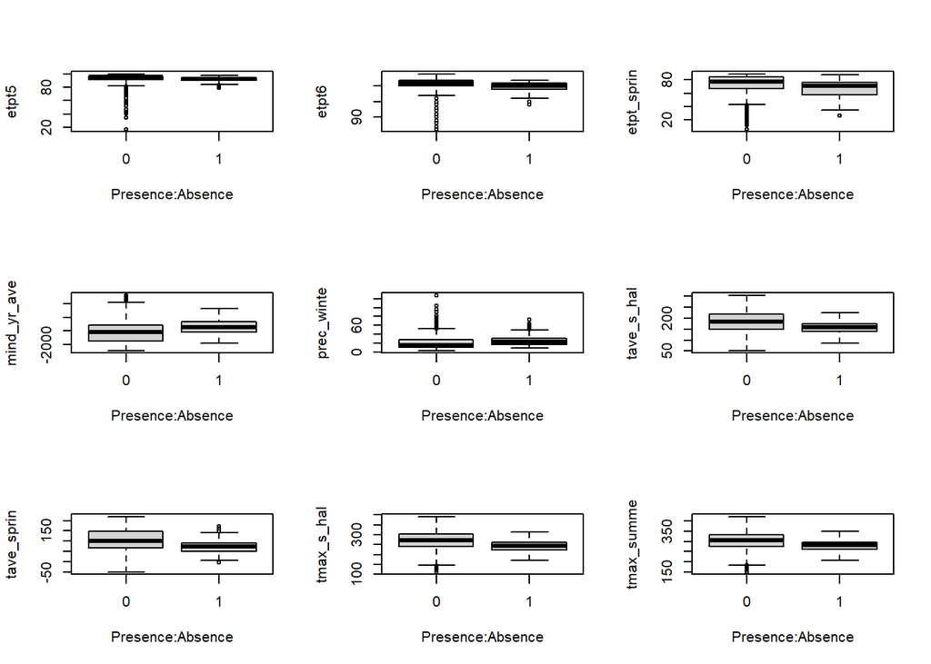

```r
#Boxplots
par(mfrow = c(3, 3))
boxplot(tr_PERS$etpt_5.img ~ tr_PERS$PERS106, xlab = "Presence:Absence",
        ylab = "etpt5", na.rm = T)
boxplot(tr_PERS$etpt_6.img ~ tr_PERS$PERS106, xlab = "Presence:Absence",
        ylab = "etpt6", na.rm = T)
boxplot(tr_PERS$etpt_sprin.img ~ tr_PERS$PERS106, xlab = "Presence:Absence",
        ylab = "etpt_sprin", na.rm = T)
boxplot(tr_PERS$mind_yr_av.img ~ tr_PERS$PERS106, xlab = "Presence:Absence",
        ylab = "mind_yr_ave", na.rm = T)
boxplot(tr_PERS$prec_winte.img ~ tr_PERS$PERS106, xlab = "Presence:Absence",
        ylab = "prec_winte", na.rm = T)
boxplot(tr_PERS$tave_s_hal.img ~ tr_PERS$PERS106, xlab = "Presence:Absence",
        ylab = "tave_s_hal", na.rm = T)
boxplot(tr_PERS$tave_sprin.img ~ tr_PERS$PERS106, xlab = "Presence:Absence",
        ylab = "tave_sprin", na.rm = T)
boxplot(tr_PERS$tmax_s_hal.img ~ tr_PERS$PERS106, xlab = "Presence:Absence",
        ylab = "tmax_s_hal", na.rm = T)
boxplot(tr_PERS$tmax_summe.img ~ tr_PERS$PERS106, xlab = "Presence:Absence",
        ylab = "tmax_summe", na.rm = T)
```

```r
par(mfrow=c(1,1))
```

## Question #2

- Construct a Random Forest (RF) model using the presence:absence data
- Build plots of variable importance values

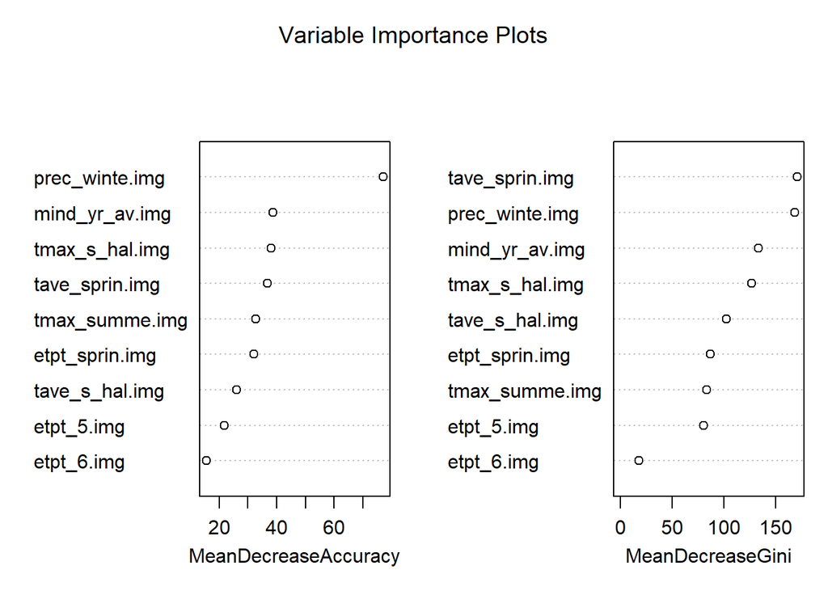

```r
pers.RF <- randomForest(mod.form(tr_PERS, 2, 5), importance = T, keep.forest=T,data = tr_PERS)
varImpPlot(pers.RF, main = "Variable Importance Plots")
```

```r
persRF.pred <- predict(pers.RF, type = 'prob')[,2]
head(persRF.pred)
```

```
##          2          3          4          5          6          7
## 0.09826590 0.71751412 0.11363636 0.01578947 0.42780749 0.01604278
```

## Question #3

- Calculate accuracy metrics (as in Module 3.2 and 3.3, Analytical Intermission) using:
  - Resubstitution approaches, and
  - A 10-fold cross–validation approach
- Extract the Out–of–Bag (OOB) estimate of model accuracy
- Compare that to the resubstitution and 10–fold cross–validation accuracy metrics

```r
# build testing dataframe using model predictions
modl <- "pers.RF.RF" # add var to keep track of model
dat2 <- cbind(modl, tr_PERS[2], persRF.pred) # build dataframe w/pers.RF predictions
head(dat2, 2) # examine prediction dataframe
```

```
##         modl PERS106 persRF.pred
## 2 pers.RF.RF       0   0.0982659
## 3 pers.RF.RF       0   0.7175141
```

```r
# determine best threshold using PresenceAbsence package Sec7.1
#   see help(optimal.thresholds) for more info
#library(PresenceAbsence) # PresenceAbsence for accuracy metrics
#help(optimal.thresholds) # options for optimizing threshold
mod.cut <- optimal.thresholds(dat2, opt.methods = c("ReqSens"), req.sens = 0.95)
mod.cut # sensitivity set at 0.95
```

```
##    Method persRF.pred
## 1 ReqSens        0.36
```

```r
#mod.cutK=optimal.thresholds(dat2,opt.methods=c('MaxKappa')); mod.cutK # MaxKappa option

# generate confusion matrix
pers.RF.cfmat <- table(dat2[[2]], factor(as.numeric(dat2$persRF.pred >= mod.cut$persRF.pred)))
pers.RF.cfmat # examine
```

```
##
##       0   1
##   0 625 331
##   1  47 939
```

```r
# calculate model accuracies with standard deviation=F
pers.RF.acc <- presence.absence.accuracy(dat2, threshold = mod.cut$persRF.pred, st.dev = F)
tss <- pers.RF.acc$sensitivity + pers.RF.acc$specificity - 1 # code TSS metric
pers.RF.acc <- cbind(pers.RF.acc[1:7], tss) # bind all metrics
pers.RF.acc[c(1, 4:5, 7:8)] # examine accuracies
```

```
##         model sensitivity specificity       AUC       tss
## 1 persRF.pred   0.9523327   0.6537657 0.8539925 0.6060983
```

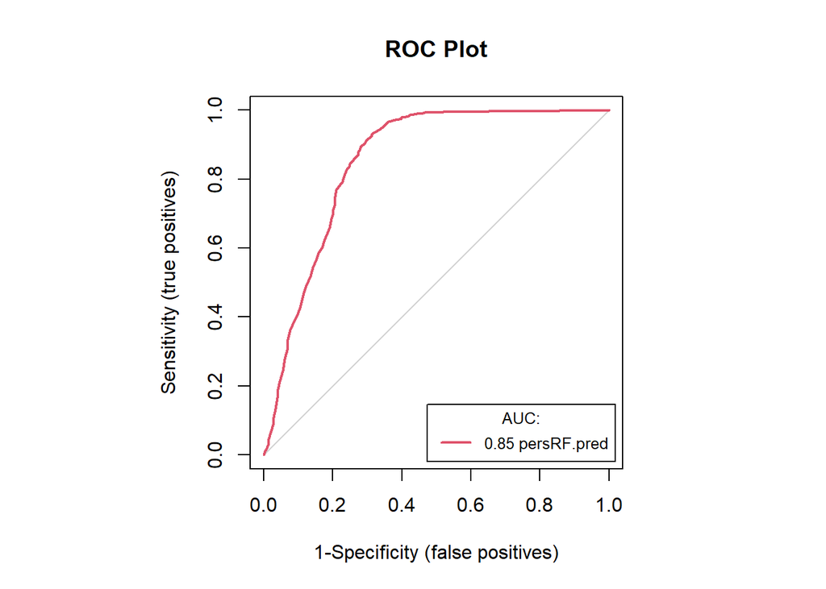

```r
# plotting AUC
auc.roc.plot(dat2, color = T) # basic AUC plot; pkg PresenceAbsence
```

```r
set.seed(1234) # set.seed for repeatability
xfold <- 10 # set No. xfolds
pers.xf <- sample(rep(c(1:xfold), length = nrow(tr_PERS))) # vector of random xfolds
pers.RF.predXF <- rep(0, length = nrow(tr_PERS)) # empty predict vector
pers.RF.sampleXF <- rep(0, length = nrow(tr_PERS)) # empty xfold vector

# simple loop for xfold
for (i in 1:xfold) {
  tr <- tr_PERS[pers.xf != i, ] # training not eq. i
  te <- tr_PERS[pers.xf == i, ] # test eq. i
  # mod1 <- mod.form(tr_PERS, 2, 5)
  RF <- randomForest(mod.form(tr_PERS, 2, 5), importance = T, keep.forest=T,data = tr)
  pers.RF.predXF[pers.xf == i]<-  predict(RF,te,type='prob')[,2]# predict to test data
  pers.RF.sampleXF[pers.xf == i] <- i #assign xfold sample to vector
} #end xfold loop
head(pers.RF.predXF) # examine vector xfold prediction
```

```
## [1] 0.084 0.696 0.154 0.024 0.428 0.014
```

```r
modl <- "pers.RF.RF"
pers.crossval <- cbind(modl,tr_PERS[2],pers.RF.predXF)
head(pers.crossval)
```

```
##         modl PERS106 pers.RF.predXF
## 2 pers.RF.RF       0          0.084
## 3 pers.RF.RF       0          0.696
## 4 pers.RF.RF       0          0.154
## 5 pers.RF.RF       0          0.024
## 6 pers.RF.RF       0          0.428
## 7 pers.RF.RF       0          0.014
```

```r
mod.cut.crossval <- optimal.thresholds(pers.crossval, opt.methods = c("ReqSens"), req.sens = 0.95)
mod.cut.crossval # sensitivity set at 0.95
```

```
##    Method pers.RF.predXF
## 1 ReqSens           0.37
```

```r
# generate confusion matrix
pers.RF.crossval.cfmat <- table(pers.crossval[[2]],
                                factor(as.numeric(pers.crossval$pers.RF.predXF >= mod.cut.crossval$pers.RF.predXF)))
pers.RF.crossval.cfmat # examine
```

```
##
##       0   1
##   0 630 326
##   1  49 937
```

```r
# calculate model accuracies with standard deviation=F
pers.RF.XF.acc <- presence.absence.accuracy(pers.crossval,
                                            threshold = mod.cut.crossval$pers.RF.predXF, st.dev = F)
tss <- pers.RF.XF.acc$sensitivity + pers.RF.XF.acc$specificity - 1 # code TSS metric
pers.RF.XF.acc <- cbind(pers.RF.XF.acc[1:7], tss) # bind all metrics
pers.RF.XF.acc[c(1, 4:5, 7:8)] # examine accuracies
```

```
##            model sensitivity specificity       AUC       tss
## 1 pers.RF.predXF   0.9503043   0.6610879 0.8571953 0.6113921
```

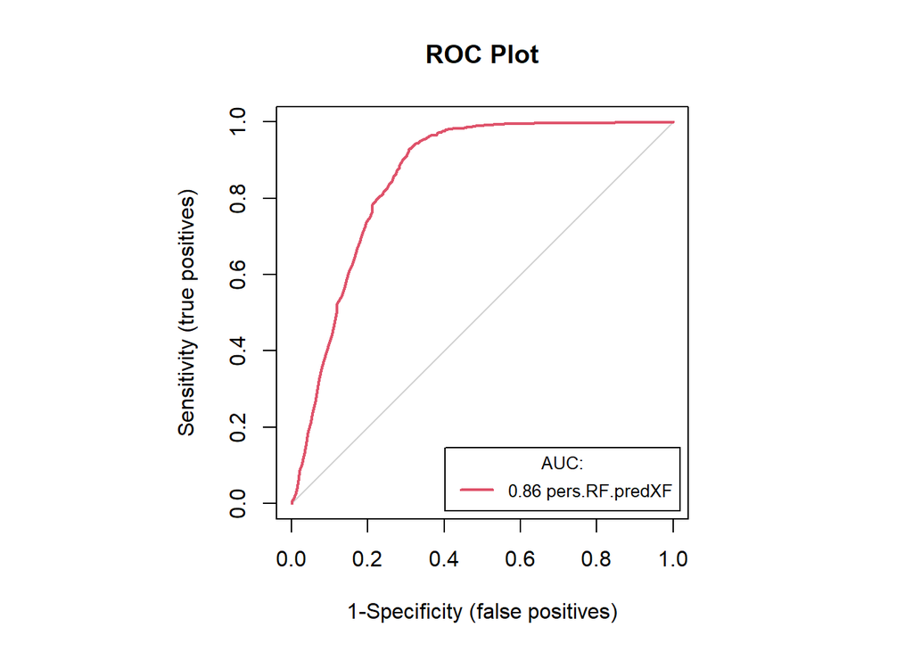

```r
# plotting AUC
auc.roc.plot(pers.crossval, color = T) # basic AUC plot; pkg PresenceAbsence
```

```r
# confusion from ReqSens=.95 option & class.error
cbind(pers.RF.cfmat, rbind(pers.RF.cfmat[3]/sum(pers.RF.cfmat[c(1, 3)]),
                        pers.RF.cfmat[2]/sum(pers.RF.cfmat[c(2, 4)])))
```

```
##     0   1
## 0 625 331 0.34623431
## 1  47 939 0.04766734
```

```r
# OOB confusion matrix & class.error
pers.RF$confusion # OOB confusion
```

```
##     0   1 class.error
## 0 694 262   0.2740586
## 1 117 869   0.1186613
```

```r
pers.RF.cfmat # specified confusion
```

```
##
##       0   1
##   0 625 331
##   1  47 939
```

```r
# OOB accuracy estimates with standard deviation=F
oob.acc <- presence.absence.accuracy(dat2, st.dev = F) # oob accuracies
tss <- oob.acc$sensitivity + oob.acc$specificity - 1 # code TSS metric
oob.acc <- cbind(oob.acc[1:7], tss) # bind all metrics
oob.acc[c(1, 4:5, 7:8)] # examine accuracies
```

```
##         model sensitivity specificity       AUC      tss
## 1 persRF.pred   0.8803245   0.7259414 0.8539925 0.606266
```

```r
pers.RF.acc[c(1, 4:5, 7:8)] # examine ReqSens accuracies
```

```
##         model sensitivity specificity       AUC       tss
## 1 persRF.pred   0.9523327   0.6537657 0.8539925 0.6060983
```

```r
pers.RF.XF.acc[c(1, 4:5, 7:8)] # examine accuracies
```

```
##            model sensitivity specificity       AUC       tss
## 1 pers.RF.predXF   0.9503043   0.6610879 0.8571953 0.6113921
```

```r
oob.acc[c(1, 4:5, 7:8)] # examine OOB accuracies
```

```
##         model sensitivity specificity       AUC      tss
## 1 persRF.pred   0.8803245   0.7259414 0.8539925 0.606266
```

## Question #4

- Build 2 prediction maps:
  - A raw probability estimate for each cell in the modelling domain; and
  - A classified map based on the selected threshold from Question #3

```r
setwd(path.gis)
states <- st_read(dsn = ".", layer = "na_states_wgs") # import shapefile
#create a probability model
setwd(path.preds)
load('pers.topoDOM.RData')
pers.dom <- pers.topoDOM
pers.prob.RF <- predict(pers.dom, pers.RF,
                         type = "prob", fun = predict, index = 2, overwrite = T) # prediction raster
pers.prob.RF # examine
```

```
## class      : RasterLayer
## dimensions : 1518, 1445, 2193510  (nrow, ncol, ncell)
## resolution : 0.008333333, 0.008333333  (x, y)
## extent     : -114.6083, -102.5667, 29.49167, 42.14167  (xmin, xmax, ymin, ymax)
## crs        : +proj=longlat +datum=WGS84 +no_defs
## source     : memory
## names      : layer
## values     : 0, 0.998  (min, max)
```

```r
# next reclassify based on threshold mod.cut per above
pers.class.RF <- reclassify(pers.prob.RF, c(0,mod.cut[[2]],0,
                                              mod.cut[[2]],1,1),overwrite=TRUE)
pers.class.RF
```

```
## class      : RasterLayer
## dimensions : 1518, 1445, 2193510  (nrow, ncol, ncell)
## resolution : 0.008333333, 0.008333333  (x, y)
## extent     : -114.6083, -102.5667, 29.49167, 42.14167  (xmin, xmax, ymin, ymax)
## crs        : +proj=longlat +datum=WGS84 +no_defs
## source     : memory
## names      : layer
## values     : 0, 1  (min, max)
```

```r
setwd(path.ex)
load("pers.bufptR.img")
# # crop(x = pers.topoDOM, y = )
#load('pers.PPsA.RData',verbose = TRUE)
# plot(pers.topoDOM)
# pers.bufR <-raster(pers.bufR)
# plot(pers.bufR)

new.pers.bufptR <- raster::projectRaster(pers.bufptR, pers.class.RF)

pers.class.RF <- pers.class.RF*new.pers.bufptR
pers.prob.RF <- pers.prob.RF*new.pers.bufptR
```

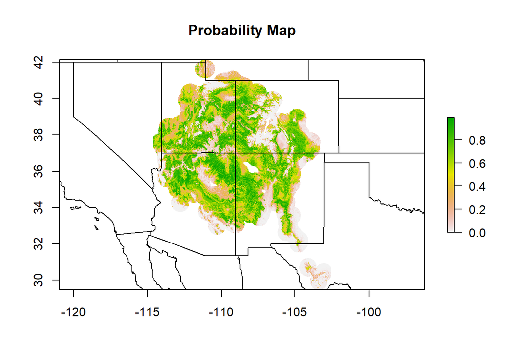

```r
par(mfrow=c(1,1))
#Plot probability map#
plot(pers.prob.RF, axes = T, main = 'Probability Map')
plot(st_geometry(states), add = T)
```

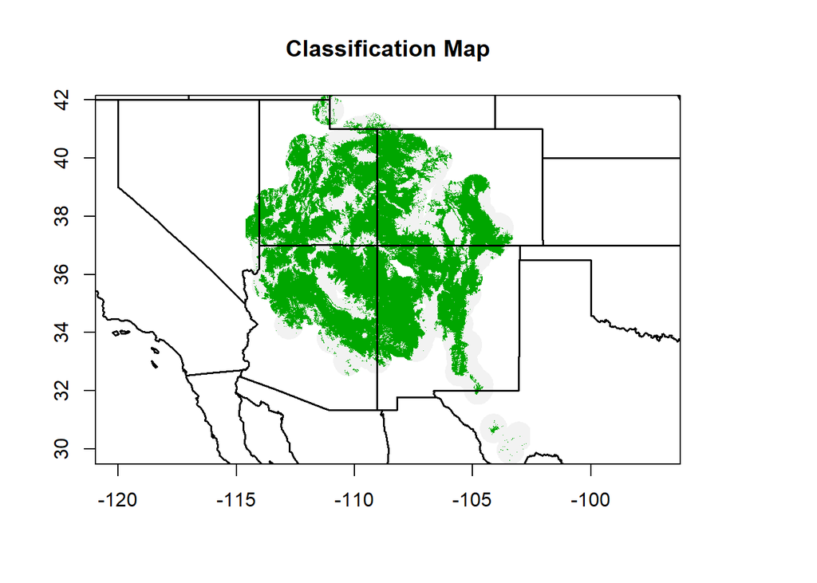

```r
#Classification Map#
plot(pers.class.RF, legend = F, axes = T, main = "Classification Map") # plot classification map
plot(st_geometry(states), add = T, lwd = 1.5) # add state boundaries
```

## Question #5

- Save your data as R objects:
  - Accuracy metrics as a dataframe;
  - Classification threshold as a stand–alone scalar
  - Both prediction maps as **`.img`** format
- Save these R objects in a **`.RData`** file

These data will be used again in Module 10, Ensemble Models.

```r
save(pers.RF,pers.class.RF,pers.prob.RF,dat2,oob.acc,pers.RF.acc, file = 'ex10.RData')
save(pers.class.RF, file = 'persClassRF.img')
save(pers.prob.RF, file = 'persProbRF.img')
```